# Exploratory Data Analysis

Ben Johnson X00229603 - https://youtu.be/HAO4wzl6y4I

```python
# import libraries
import pandas as pd
import numpy as np
import matplotlib.pyplot as plt
import seaborn as sns
```

```python
# loading the data
df = pd.read_csv('CA2_data.csv')
```

```python
# check the data head
df.head(3)
```

|  | Age | Attrition | BusinessTravel | DailyRate | Department | DistanceFromHome | Education | EducationField | EmployeeCount | EmployeeNumber | ... | RelationshipSatisfaction | StandardHours | StockOptionLevel | TotalWorkingYears | TrainingTimesLastYear | WorkLifeBalance | YearsAtCompany | YearsInCurrentRole | YearsSinceLastPromotion | YearsWithCurrManager |
| --- | --- | --- | --- | --- | --- | --- | --- | --- | --- | --- | --- | --- | --- | --- | --- | --- | --- | --- | --- | --- | --- |
| 0 | 41 | Yes | Travel_Rarely | 1102 | Sales | 1 | College | Life Sciences | 1 | 1 | ... | 1 | 80 | 0 | 8 | 0 | Bad | 6 | 4 | 0 | 5 |
| 1 | 49 | No | Travel_Frequently | 279 | Research & Development | 8 | Below College | Life Sciences | 1 | 2 | ... | 4 | 80 | 1 | 10 | 3 | Better | 10 | 7 | 1 | 7 |
| 2 | 37 | Yes | Travel_Rarely | 1373 | Research & Development | 2 | College | Other | 1 | 4 | ... | 2 | 80 | 0 | 7 | 3 | Better | 0 | 0 | 0 | 0 |

3 rows × 35 columns

```python
# basic df information
df.info()
```

```
<class 'pandas.core.frame.DataFrame'>
RangeIndex: 1470 entries, 0 to 1469
Data columns (total 35 columns):
 #   Column                    Non-Null Count  Dtype
---  ------                    --------------  -----
 0   Age                       1470 non-null   int64
 1   Attrition                 1470 non-null   object
 2   BusinessTravel            1470 non-null   object
 3   DailyRate                 1470 non-null   int64
 4   Department                1470 non-null   object
 5   DistanceFromHome          1470 non-null   int64
 6   Education                 1470 non-null   object
 7   EducationField            1470 non-null   object
 8   EmployeeCount             1470 non-null   int64
 9   EmployeeNumber            1470 non-null   int64
```

[output cut: 27 more lines]

```python
# data shape
df.shape
```

```
(1470, 35)
```

```python
# check datatypes
df.dtypes
```

|  | 0 |
| --- | --- |
| Age | int64 |
| Attrition | object |
| BusinessTravel | object |
| DailyRate | int64 |
| Department | object |
| DistanceFromHome | int64 |
| Education | object |
| EducationField | object |
| EmployeeCount | int64 |
| EmployeeNumber | int64 |
| EnvironmentSatisfaction | object |
| Gender | object |
| HourlyRate | int64 |
| JobInvolvement | int64 |
| JobLevel | int64 |
| JobRole | object |
| JobSatisfaction | object |
| MaritalStatus | object |
| MonthlyIncome | object |
| MonthlyRate | object |
| NumCompaniesWorked | int64 |
| Over18 | object |
| OverTime | object |
| PercentSalaryHike | int64 |
| PerformanceRating | int64 |
| RelationshipSatisfaction | int64 |
| StandardHours | int64 |
| StockOptionLevel | int64 |
| TotalWorkingYears | int64 |
| TrainingTimesLastYear | int64 |
| WorkLifeBalance | object |
| YearsAtCompany | int64 |
| YearsInCurrentRole | int64 |
| YearsSinceLastPromotion | int64 |
| YearsWithCurrManager | int64 |

**dtype:** object

```python
# describe numerical data
df.describe()
```

|  | Age | DailyRate | DistanceFromHome | EmployeeCount | EmployeeNumber | HourlyRate | JobInvolvement | JobLevel | NumCompaniesWorked | PercentSalaryHike | PerformanceRating | RelationshipSatisfaction | StandardHours | StockOptionLevel | TotalWorkingYears | TrainingTimesLastYear | YearsAtCompany | YearsInCurrentRole | YearsSinceLastPromotion | YearsWithCurrManager |
| --- | --- | --- | --- | --- | --- | --- | --- | --- | --- | --- | --- | --- | --- | --- | --- | --- | --- | --- | --- | --- |
| count | 1470.000000 | 1470.000000 | 1470.000000 | 1470.0 | 1470.000000 | 1470.000000 | 1470.000000 | 1470.000000 | 1470.000000 | 1470.000000 | 1470.000000 | 1470.000000 | 1470.0 | 1470.000000 | 1470.000000 | 1470.000000 | 1470.000000 | 1470.000000 | 1470.000000 | 1470.000000 |
| mean | 36.923810 | 802.485714 | 9.192517 | 1.0 | 1024.865306 | 65.891156 | 2.729932 | 2.063946 | 2.693197 | 15.209524 | 3.153741 | 2.712245 | 80.0 | 0.793878 | 11.279592 | 2.799320 | 7.008163 | 4.229252 | 2.187755 | 4.123129 |
| std | 9.135373 | 403.509100 | 8.106864 | 0.0 | 602.024335 | 20.329428 | 0.711561 | 1.106940 | 2.498009 | 3.659938 | 0.360824 | 1.081209 | 0.0 | 0.852077 | 7.780782 | 1.289271 | 6.126525 | 3.623137 | 3.222430 | 3.568136 |
| min | 18.000000 | 102.000000 | 1.000000 | 1.0 | 1.000000 | 30.000000 | 1.000000 | 1.000000 | 0.000000 | 11.000000 | 3.000000 | 1.000000 | 80.0 | 0.000000 | 0.000000 | 0.000000 | 0.000000 | 0.000000 | 0.000000 | 0.000000 |
| 25% | 30.000000 | 465.000000 | 2.000000 | 1.0 | 491.250000 | 48.000000 | 2.000000 | 1.000000 | 1.000000 | 12.000000 | 3.000000 | 2.000000 | 80.0 | 0.000000 | 6.000000 | 2.000000 | 3.000000 | 2.000000 | 0.000000 | 2.000000 |
| 50% | 36.000000 | 802.000000 | 7.000000 | 1.0 | 1020.500000 | 66.000000 | 3.000000 | 2.000000 | 2.000000 | 14.000000 | 3.000000 | 3.000000 | 80.0 | 1.000000 | 10.000000 | 3.000000 | 5.000000 | 3.000000 | 1.000000 | 3.000000 |
| 75% | 43.000000 | 1157.000000 | 14.000000 | 1.0 | 1555.750000 | 83.750000 | 3.000000 | 3.000000 | 4.000000 | 18.000000 | 3.000000 | 4.000000 | 80.0 | 1.000000 | 15.000000 | 3.000000 | 9.000000 | 7.000000 | 3.000000 | 7.000000 |
| max | 60.000000 | 1499.000000 | 29.000000 | 1.0 | 2068.000000 | 100.000000 | 4.000000 | 5.000000 | 9.000000 | 25.000000 | 4.000000 | 4.000000 | 80.0 | 3.000000 | 40.000000 | 6.000000 | 40.000000 | 18.000000 | 15.000000 | 17.000000 |

```python
# describe categorical data
df.describe(include='object')
```

|  | Attrition | BusinessTravel | Department | Education | EducationField | EnvironmentSatisfaction | Gender | JobRole | JobSatisfaction | MaritalStatus | MonthlyIncome | MonthlyRate | Over18 | OverTime | WorkLifeBalance |
| --- | --- | --- | --- | --- | --- | --- | --- | --- | --- | --- | --- | --- | --- | --- | --- |
| count | 1470 | 1470 | 1470 | 1470 | 1470 | 1470 | 1470 | 1470 | 1470 | 1470 | 1470 | 1470 | 1470 | 1470 | 1470 |
| unique | 2 | 3 | 3 | 5 | 6 | 4 | 2 | 9 | 4 | 3 | 1350 | 1427 | 1 | 2 | 4 |
| top | No | Travel_Rarely | Research & Development | Bachelor | Life Sciences | High | Male | Sales Executive | Very High | Married | 2342 | 4223 | Y | No | Better |
| freq | 1233 | 1043 | 961 | 572 | 606 | 453 | 882 | 326 | 459 | 673 | 4 | 3 | 1470 | 1054 | 893 |

```python
# check for nulls
df.isnull().sum()
```

|  | 0 |
| --- | --- |
| Age | 0 |
| Attrition | 0 |
| BusinessTravel | 0 |
| DailyRate | 0 |
| Department | 0 |
| DistanceFromHome | 0 |
| Education | 0 |
| EducationField | 0 |
| EmployeeCount | 0 |
| EmployeeNumber | 0 |
| EnvironmentSatisfaction | 0 |
| Gender | 0 |
| HourlyRate | 0 |
| JobInvolvement | 0 |
| JobLevel | 0 |
| JobRole | 0 |
| JobSatisfaction | 0 |
| MaritalStatus | 0 |
| MonthlyIncome | 0 |
| MonthlyRate | 0 |
| NumCompaniesWorked | 0 |
| Over18 | 0 |
| OverTime | 0 |
| PercentSalaryHike | 0 |
| PerformanceRating | 0 |
| RelationshipSatisfaction | 0 |
| StandardHours | 0 |
| StockOptionLevel | 0 |
| TotalWorkingYears | 0 |
| TrainingTimesLastYear | 0 |
| WorkLifeBalance | 0 |
| YearsAtCompany | 0 |
| YearsInCurrentRole | 0 |
| YearsSinceLastPromotion | 0 |
| YearsWithCurrManager | 0 |

**dtype:** int64

```python
# check for duplicates
df.duplicated().sum()
```

```
0
```

```python
# check for column name issues
df.columns
```

```
Index(['Age', 'Attrition', 'BusinessTravel', 'DailyRate', 'Department',
       'DistanceFromHome', 'Education', 'EducationField', 'EmployeeCount',
       'EmployeeNumber', 'EnvironmentSatisfaction', 'Gender', 'HourlyRate',
       'JobInvolvement', 'JobLevel', 'JobRole', 'JobSatisfaction',
       'MaritalStatus', 'MonthlyIncome', 'MonthlyRate', 'NumCompaniesWorked',
       'Over18', 'OverTime', 'PercentSalaryHike', 'PerformanceRating',
       'RelationshipSatisfaction', 'StandardHours', 'StockOptionLevel',
       'TotalWorkingYears', 'TrainingTimesLastYear', 'WorkLifeBalance',
       'YearsAtCompany', 'YearsInCurrentRole', 'YearsSinceLastPromotion',
       'YearsWithCurrManager'],
      dtype='object')
```

## Investigating "EmployeeCount"

We can drop EmployeeCount as each entry already represents 1 employee. In short, this is duplicated data.

```python
df.EmployeeCount.value_counts()
```

| EmployeeCount | count |
| --- | --- |
| 1 | 1470 |

**dtype:** int64

```python
df.drop('EmployeeCount', axis=1, inplace=True)
```

## Investigating "StandardHours"

All entries are "80", so we can drop this column to reduce dimensionality.

```python
df.StandardHours.value_counts()
```

| StandardHours | count |
| --- | --- |
| 80 | 1470 |

**dtype:** int64

```python
df.drop('StandardHours', axis=1, inplace=True)
```

```python
df.shape
```

```
(1470, 33)
```

## Investigating "MonthlyIncome", "MonthlyRate" & "DailyRate"

The first two columns are identified as categorical because they are strings. We will convert the values to integers before handling the data. The columns have 1350 & 1427 unique entries respectively.

The DailyRate column will also be binned for simplicity & understandability.

```python
# converting columns to numerical
df['MonthlyIncome'] = pd.to_numeric(df['MonthlyIncome'], errors='coerce')
df['MonthlyRate'] = pd.to_numeric(df['MonthlyRate'], errors='coerce')
```

```python
df['MonthlyIncome'].describe()
```

|  | MonthlyIncome |
| --- | --- |
| count | 1469.000000 |
| mean | 6503.278421 |
| std | 4709.541219 |
| min | 1009.000000 |
| 25% | 2911.000000 |
| 50% | 4908.000000 |
| 75% | 8380.000000 |
| max | 19999.000000 |

**dtype:** float64

```python
df['MonthlyRate'].describe()
```

|  | MonthlyRate |
| --- | --- |
| count | 1469.000000 |
| mean | 14309.586794 |
| std | 7118.932398 |
| min | 2094.000000 |
| 25% | 8045.000000 |
| 50% | 14229.000000 |
| 75% | 20462.000000 |
| max | 26999.000000 |

**dtype:** float64

```python
# using quantile-based binning for MonthlyIncome
num_bins = 5

df['MonthlyIncome_Binned'] = pd.qcut(df['MonthlyIncome'], q=num_bins, labels=False)

df = df.drop('MonthlyIncome', axis=1)
```

```python
# using quantile-based binning for MonthlyRate
num_bins = 5

df['MonthlyRate_Binned'] = pd.qcut(df['MonthlyRate'], q=num_bins, labels=False)

df = df.drop('MonthlyRate', axis=1)
```

```python
df.head(2)
```

|  | Age | Attrition | BusinessTravel | DailyRate | Department | DistanceFromHome | Education | EducationField | EmployeeNumber | EnvironmentSatisfaction | ... | StockOptionLevel | TotalWorkingYears | TrainingTimesLastYear | WorkLifeBalance | YearsAtCompany | YearsInCurrentRole | YearsSinceLastPromotion | YearsWithCurrManager | MonthlyIncome_Binned | MonthlyRate_Binned |
| --- | --- | --- | --- | --- | --- | --- | --- | --- | --- | --- | --- | --- | --- | --- | --- | --- | --- | --- | --- | --- | --- |
| 0 | 41 | Yes | Travel_Rarely | 1102 | Sales | 1 | College | Life Sciences | 1 | Medium | ... | 0 | 8 | 0 | Bad | 6 | 4 | 0 | 5 | NaN | NaN |
| 1 | 49 | No | Travel_Frequently | 279 | Research & Development | 8 | Below College | Life Sciences | 2 | High | ... | 1 | 10 | 3 | Better | 10 | 7 | 1 | 7 | 2.0 | 4.0 |

2 rows × 33 columns

```python
# drop first row due to binned NaN
df = df.drop(df.index[0])
```

```python
# using quantile-based binning for DailyRate
num_bins = 5

df['DailyRate_Binned'] = pd.qcut(df['DailyRate'], q=num_bins, labels=False)

df = df.drop('DailyRate', axis=1)
```

```python
df.head(2)
```

|  | Age | Attrition | BusinessTravel | Department | DistanceFromHome | Education | EducationField | EmployeeNumber | EnvironmentSatisfaction | Gender | ... | TotalWorkingYears | TrainingTimesLastYear | WorkLifeBalance | YearsAtCompany | YearsInCurrentRole | YearsSinceLastPromotion | YearsWithCurrManager | MonthlyIncome_Binned | MonthlyRate_Binned | DailyRate_Binned |
| --- | --- | --- | --- | --- | --- | --- | --- | --- | --- | --- | --- | --- | --- | --- | --- | --- | --- | --- | --- | --- | --- |
| 1 | 49 | No | Travel_Frequently | Research & Development | 8 | Below College | Life Sciences | 2 | High | Male | ... | 10 | 3 | Better | 10 | 7 | 1 | 7 | 2.0 | 4.0 | 0 |
| 2 | 37 | Yes | Travel_Rarely | Research & Development | 2 | College | Other | 4 | Very High | Male | ... | 7 | 3 | Better | 0 | 0 | 0 | 0 | 0.0 | 0.0 | 4 |

2 rows × 33 columns

# Addressing multi-collinearity

## Chi-Square Test

```python
from sklearn.feature_selection import SelectKBest, chi2

# apply Chi-Square Test
X = df.drop(columns=['Attrition'])
y = df['Attrition'].map({'No': 0, 'Yes': 1})

chi2_selector = SelectKBest(chi2, k=12)
chi2_selector.fit(X.select_dtypes(include=['int64', 'float64']), y)

selected_features = X.select_dtypes(include=['int64', 'float64']).columns[chi2_selector.get_support()]
print("Top features based on Chi-Square Test:", selected_features)
```

```
Top features based on Chi-Square Test: Index(['Age', 'DistanceFromHome', 'EmployeeNumber', 'JobLevel',
       'StockOptionLevel', 'TotalWorkingYears', 'YearsAtCompany',
       'YearsInCurrentRole', 'YearsSinceLastPromotion', 'YearsWithCurrManager',
       'MonthlyIncome_Binned', 'DailyRate_Binned'],
      dtype='object')
```

## Correlation values for numerical features

```python
df['Attrition'] = df['Attrition'].map({'Yes': 1, 'No': 0})

numerical_df = df.select_dtypes(include=np.number)

corr_matrix = numerical_df.corr()

print(corr_matrix['Attrition'].abs().sort_values(ascending=False))
```

```
Attrition                   1.000000
MonthlyIncome_Binned        0.188696
TotalWorkingYears           0.170721
JobLevel                    0.169315
YearsInCurrentRole          0.160732
Age                         0.160193
YearsWithCurrManager        0.156862
StockOptionLevel            0.135979
YearsAtCompany              0.134376
JobInvolvement              0.130844
DistanceFromHome            0.079662
DailyRate_Binned            0.065320
TrainingTimesLastYear       0.056295
RelationshipSatisfaction    0.043527
NumCompaniesWorked          0.040327
YearsSinceLastPromotion     0.032026
PercentSalaryHike           0.011718
MonthlyRate_Binned          0.009173
HourlyRate                  0.009015
EmployeeNumber              0.007958
PerformanceRating           0.003557
Name: Attrition, dtype: float64
```

```python
from scipy.stats import pearsonr

significant_features = {}
for col in numerical_df.columns:
    if col != 'Attrition':
        r, p_value = pearsonr(numerical_df[col], numerical_df['Attrition'])
        significant_features[col] = (r, p_value)

significant_features = {k: v for k, v in significant_features.items() if v[1] < 0.05}
significant_features
```

```
{'Age': (-0.16019281265762783, 6.637984518631358e-10),
 'DistanceFromHome': (0.07966206821197985, 0.0022467918776786972),
 'JobInvolvement': (-0.1308437797075235, 4.846330675269237e-07),
 'JobLevel': (-0.1693153016504929, 6.527864833306446e-11),
 'StockOptionLevel': (-0.13597892649716084, 1.680333705423111e-07),
 'TotalWorkingYears': (-0.17072145458134189, 4.513181098908146e-11),
 'TrainingTimesLastYear': (-0.056295457848470065, 0.03096357152804414),
 'YearsAtCompany': (-0.13437601805774288, 2.3487361441709296e-07),
 'YearsInCurrentRole': (-0.16073181600227635, 5.808799323343044e-10),
 'YearsWithCurrManager': (-0.15686225540154689, 1.4989201774962149e-09),
 'MonthlyIncome_Binned': (-0.18869577882995586, 3.061003119884917e-13),
 'DailyRate_Binned': (-0.06531996667321822, 0.012276446052451527)}
```

## Selected Features Based on Chi-Square Test and Correlation Analysis

The following features display moderate correlation with attrition or were identified by the Chi-Square test as important contributors to the predictive power of the model:

[output not shown]

```python
# reduce dataset to these identified features
selected_features = [
    "MonthlyIncome_Binned",
    "TotalWorkingYears",
    "JobLevel",
    "YearsInCurrentRole",
    "Age",
    "YearsWithCurrManager",
    "StockOptionLevel",
    "YearsAtCompany",
    "JobInvolvement",
    "DistanceFromHome",
    "YearsSinceLastPromotion",
    "DailyRate_Binned",
    "TrainingTimesLastYear",
    "RelationshipSatisfaction",
    "NumCompaniesWorked"
]

df = df[selected_features + ['Attrition']]
```

```python
df.head(3)
```

|  | MonthlyIncome_Binned | TotalWorkingYears | JobLevel | YearsInCurrentRole | Age | YearsWithCurrManager | StockOptionLevel | YearsAtCompany | JobInvolvement | DistanceFromHome | YearsSinceLastPromotion | DailyRate_Binned | TrainingTimesLastYear | RelationshipSatisfaction | NumCompaniesWorked | Attrition |
| --- | --- | --- | --- | --- | --- | --- | --- | --- | --- | --- | --- | --- | --- | --- | --- | --- |
| 1 | 2.0 | 10 | 2 | 7 | 49 | 7 | 1 | 10 | 2 | 8 | 1 | 0 | 3 | 4 | 1 | 0 |
| 2 | 0.0 | 7 | 1 | 0 | 37 | 0 | 0 | 0 | 2 | 2 | 0 | 4 | 3 | 2 | 6 | 1 |
| 3 | 1.0 | 8 | 1 | 7 | 33 | 0 | 0 | 8 | 3 | 3 | 3 | 4 | 3 | 3 | 1 | 0 |

# Data Visualisation

## Attrition Distribution

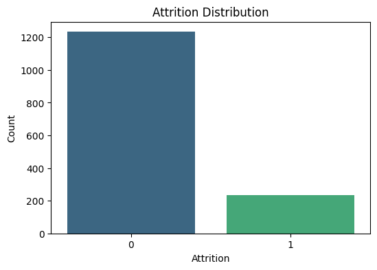

```python
plt.figure(figsize=(6, 4))
sns.countplot(x="Attrition", data=df, palette="viridis")
plt.title("Attrition Distribution")
plt.xlabel("Attrition")
plt.ylabel("Count")
plt.show()
```

## Age vs. Attrition

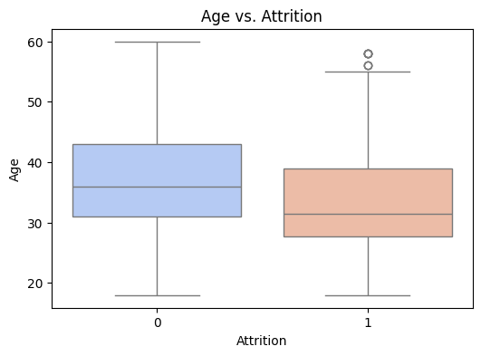

```python
plt.figure(figsize=(6, 4))
sns.boxplot(x="Attrition", y="Age", data=df, palette="coolwarm")
plt.title("Age vs. Attrition")
plt.xlabel("Attrition")
plt.ylabel("Age")
plt.show()
```

## Monthly Income vs. Job Level

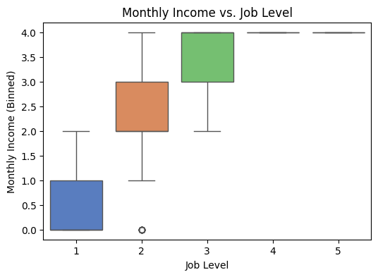

```python
plt.figure(figsize=(6, 4))
sns.boxplot(x="JobLevel", y="MonthlyIncome_Binned", data=df, palette="muted")
plt.title("Monthly Income vs. Job Level")
plt.xlabel("Job Level")
plt.ylabel("Monthly Income (Binned)")
plt.show()
```

## Years at Company vs. Attrition

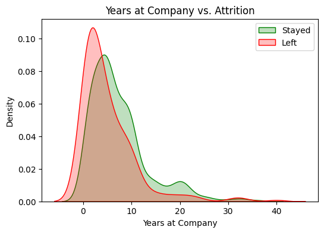

```python
plt.figure(figsize=(6, 4))
sns.kdeplot(data=df[df["Attrition"] == 0], x="YearsAtCompany", fill=True, label="Stayed", color="green")
sns.kdeplot(data=df[df["Attrition"] == 1], x="YearsAtCompany", fill=True, label="Left", color="red")
plt.title("Years at Company vs. Attrition")
plt.xlabel("Years at Company")
plt.ylabel("Density")
plt.legend()
plt.show()
```

## Relationship Satisfaction vs. Attrition

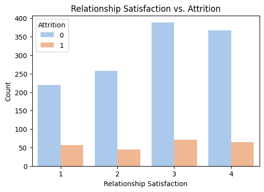

```python
plt.figure(figsize=(6, 4))
sns.countplot(x="RelationshipSatisfaction", hue="Attrition", data=df, palette="pastel")
plt.title("Relationship Satisfaction vs. Attrition")
plt.xlabel("Relationship Satisfaction")
plt.ylabel("Count")
plt.legend(title="Attrition")
plt.show()
```

## Distance from Home vs. Attrition

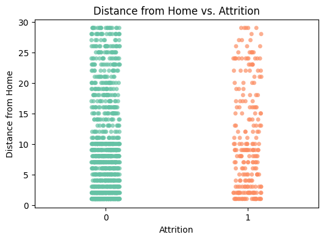

```python
plt.figure(figsize=(6, 4))
sns.stripplot(x="Attrition", y="DistanceFromHome", data=df, jitter=True, palette="Set2", alpha=0.7)
plt.title("Distance from Home vs. Attrition")
plt.xlabel("Attrition")
plt.ylabel("Distance from Home")
plt.show()
```

# Fairness Investigation

```python
# splitting the data into train and test
from sklearn.model_selection import train_test_split
train_df, test_df = train_test_split(df, test_size=0.2, random_state=42)
```

```python
from google.colab import widgets
from IPython.core.display import display, HTML
import base64
!pip install tensorflow==2.15.1
!pip install facets-overview==1.1.1
from facets_overview.feature_statistics_generator import FeatureStatisticsGenerator
```

```python
fsg = FeatureStatisticsGenerator()
dataframes = [
    {'table': train_df, 'name': 'trainData'}]
censusProto = fsg.ProtoFromDataFrames(dataframes)
protostr = base64.b64encode(censusProto.SerializeToString()).decode("utf-8")


HTML_TEMPLATE = """<script src="https://cdnjs.cloudflare.com/ajax/libs/webcomponentsjs/1.3.3/webcomponents-lite.js"></script>
        <link rel="import" href="https://raw.githubusercontent.com/PAIR-code/facets/1.0.0/facets-dist/facets-jupyter.html">
        <facets-overview id="elem"></facets-overview>
        <script>
          document.querySelector("#elem").protoInput = "{protostr}";
        </script>"""
html = HTML_TEMPLATE.format(protostr=protostr)
display(HTML(html))
```

```python
SAMPLE_SIZE = 1175

train_dive = train_df.sample(SAMPLE_SIZE).to_json(orient='records')

HTML_TEMPLATE = """<script src="https://cdnjs.cloudflare.com/ajax/libs/webcomponentsjs/1.3.3/webcomponents-lite.js"></script>
        <link rel="import" href="https://raw.githubusercontent.com/PAIR-code/facets/1.0.0/facets-dist/facets-jupyter.html">
        <facets-dive id="elem" height="600"></facets-dive>
        <script>
          var data = {jsonstr};
          document.querySelector("#elem").data = data;
        </script>"""
html = HTML_TEMPLATE.format(jsonstr=train_dive)
display(HTML(html))
```

# Statistical Analysis

## Correlation Matrix

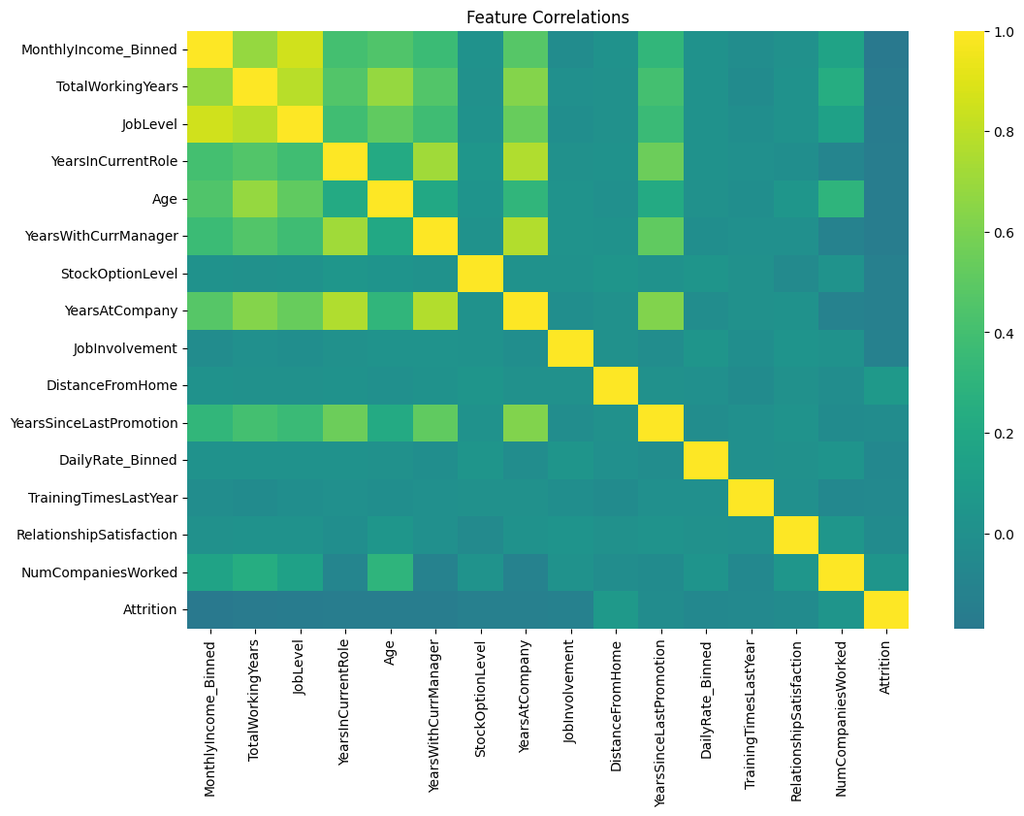

```python
# correlation matrix
corr = df.select_dtypes(include=np.number).corr()
plt.figure(figsize=(12,8))
sns.heatmap(corr, cmap='viridis', center=0)
plt.title('Feature Correlations')
plt.show()
```

```python
# dropping columns based on correlation matrix
df = df.drop(columns=["YearsSinceLastPromotion", "DailyRate_Binned", "TrainingTimesLastYear", "RelationshipSatisfaction"])
```

```python
# latest df
df.head(3)
```

|  | MonthlyIncome_Binned | TotalWorkingYears | JobLevel | YearsInCurrentRole | Age | YearsWithCurrManager | StockOptionLevel | YearsAtCompany | JobInvolvement | DistanceFromHome | NumCompaniesWorked | Attrition |
| --- | --- | --- | --- | --- | --- | --- | --- | --- | --- | --- | --- | --- |
| 1 | 2.0 | 10 | 2 | 7 | 49 | 7 | 1 | 10 | 2 | 8 | 1 | 0 |
| 2 | 0.0 | 7 | 1 | 0 | 37 | 0 | 0 | 0 | 2 | 2 | 6 | 1 |
| 3 | 1.0 | 8 | 1 | 7 | 33 | 0 | 0 | 8 | 3 | 3 | 1 | 0 |

## Principal Component Analysis (PCA)

```python
from sklearn.decomposition import PCA
from sklearn.preprocessing import StandardScaler
```

```python
# select and scale only numeric features
df_numeric = df.select_dtypes(include=np.number)

scaler = StandardScaler()
df_scaled = scaler.fit_transform(df_numeric)
```

```python
# fit the PCA model to the scaled data and transform it
pca = PCA()
pca_components = pca.fit_transform(df_scaled)
```

```python
# calculate the cumulative explained variance ratio
explained_variance = np.cumsum(pca.explained_variance_ratio_)
```

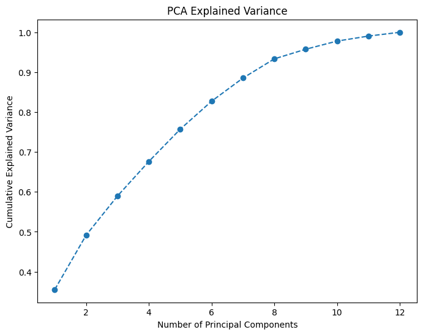

```python
# plot cumulative explained variance to determine the optimal number of features
plt.figure(figsize=(8, 6))
plt.plot(range(1, len(explained_variance) + 1), explained_variance, marker='o', linestyle='--')
plt.xlabel('Number of Principal Components')
plt.ylabel('Cumulative Explained Variance')
plt.title('PCA Explained Variance')
plt.show()
```

The PCA Explained Variance Diagram is showing diminishing returns after the 9th or 10th component, where >95% of variance is explained. We can try a hypothesis test and MLR in order to identify the final feature to remove.

## Hypothesis testing

```python
# one-way ANOVA test for weak explanatory variables
from scipy.stats import f_oneway

continuous_vars = ['NumCompaniesWorked', "TotalWorkingYears"]
for var in continuous_vars:
    groups = [group[var].values for name, group in df.groupby('Attrition')]
    f_stat, p_value = f_oneway(*groups)
    print(f"ANOVA test for {var}: p-value={p_value}")
```

```
ANOVA test for NumCompaniesWorked: p-value=0.12235477456847998
ANOVA test for TotalWorkingYears: p-value=4.513181098909133e-11
```

## Multiple Linear Regression

```python
import statsmodels.api as sm
```

```python
# drop target variable
X = df.drop(['Attrition'], axis=1)
X = pd.get_dummies(X, drop_first=True)
```

```python
# convert all columns in X to numeric and drop NaNs
X = X.apply(pd.to_numeric, errors='coerce')
X.dropna(inplace=True)
```

```python
# align target variable with the rows in the feature matrix X
y = df['Attrition']
y = y[X.index]
```

```python
# adding a constant
X = sm.add_constant(X)
```

```python
# identify boolean columns
bool_cols = X.select_dtypes(include=['bool']).columns
print("Boolean columns:", bool_cols)
```

```
Boolean columns: Index([], dtype='object')
```

```python
# convert boolean values to integers
X[bool_cols] = X[bool_cols].astype(int)
```

```python
# run OLS model
model = sm.OLS(y, X).fit()
print(model.summary())
```

```
                            OLS Regression Results
==============================================================================
Dep. Variable:              Attrition   R-squared:                       0.105
Model:                            OLS   Adj. R-squared:                  0.098
Method:                 Least Squares   F-statistic:                     15.48
Date:                Sun, 05 Jan 2025   Prob (F-statistic):           6.52e-29
Time:                        11:34:59   Log-Likelihood:                -531.57
No. Observations:                1469   AIC:                             1087.
Df Residuals:                    1457   BIC:                             1151.
Df Model:                          11
Covariance Type:            nonrobust
========================================================================================
                           coef    std err          t      P>|t|      [0.025      0.975]
----------------------------------------------------------------------------------------
const                    0.5563      0.057      9.746      0.000       0.444       0.668
MonthlyIncome_Binned    -0.0403      0.013     -3.184      0.001      -0.065      -0.015
TotalWorkingYears       -0.0023      0.003     -0.928      0.354      -0.007       0.003
JobLevel                 0.0125      0.019      0.658      0.511      -0.025       0.050
YearsInCurrentRole      -0.0084      0.004     -2.052      0.040      -0.017      -0.000
Age                     -0.0041      0.001     -2.941      0.003      -0.007      -0.001
YearsWithCurrManager    -0.0095      0.004     -2.241      0.025      -0.018      -0.001
StockOptionLevel        -0.0558      0.011     -5.197      0.000      -0.077      -0.035
YearsAtCompany           0.0076      0.003      2.496      0.013       0.002       0.014
JobInvolvement          -0.0653      0.013     -5.079      0.000      -0.091      -0.040
DistanceFromHome         0.0043      0.001      3.789      0.000       0.002       0.006
NumCompaniesWorked       0.0160      0.004      3.920      0.000       0.008       0.024
==============================================================================
Omnibus:                      371.626   Durbin-Watson:                   1.971
Prob(Omnibus):                  0.000   Jarque-Bera (JB):              703.769
Skew:                           1.587   Prob(JB):                    1.51e-153
Kurtosis:                       4.191   Cond. No.                         269.
==============================================================================

Notes:
[1] Standard Errors assume that the covariance matrix of the errors is correctly specified.
```

TotalWorkingYears was removed from the model because its p-value (0.354) in the OLS regression results indicates it is not statistically significant at the common threshold of 0.05. This suggests that TotalWorkingYears does not provide meaningful explanatory power for predicting Attrition when other variables are accounted for.

```python
# identify statistically significant variables based on p-values
significant_vars = model.pvalues[model.pvalues < 0.05].index.tolist()
```

```python
# quick look
significant_vars.remove('const')
significant_vars
```

```
['MonthlyIncome_Binned',
 'YearsInCurrentRole',
 'Age',
 'YearsWithCurrManager',
 'StockOptionLevel',
 'YearsAtCompany',
 'JobInvolvement',
 'DistanceFromHome',
 'NumCompaniesWorked']
```

```python
# drop TotalWorkingYears
df = df.drop('TotalWorkingYears', axis=1)
```

```python
# final dataframe
df.head(3)
```

|  | MonthlyIncome_Binned | JobLevel | YearsInCurrentRole | Age | YearsWithCurrManager | StockOptionLevel | YearsAtCompany | JobInvolvement | DistanceFromHome | NumCompaniesWorked | Attrition |
| --- | --- | --- | --- | --- | --- | --- | --- | --- | --- | --- | --- |
| 1 | 2.0 | 2 | 7 | 49 | 7 | 1 | 10 | 2 | 8 | 1 | 0 |
| 2 | 0.0 | 1 | 0 | 37 | 0 | 0 | 0 | 2 | 2 | 6 | 1 |
| 3 | 1.0 | 1 | 7 | 33 | 0 | 0 | 8 | 3 | 3 | 1 | 0 |

```python
# exporting df as CSV (uncomment if needed)
# df.to_csv('JohnsonCA2.csv', index=False)
```

# Image Preprocessing

```python
import tensorflow as tf
from tensorflow import keras

# load the Fashion-MNIST dataset
(x_train, y_train), (x_test, y_test) = keras.datasets.fashion_mnist.load_data()
```

The images are classified as follows:

- 0 T-shirt/top
- 1 Trouser
- 2 Pullover
- 3 Dress
- 4 Coat
- 5 Sandal
- 6 Shirt
- 7 Sneaker
- 8 Bag
- 9 Ankle boot

```python
# create array of types
class_names = ['T-shirt/top', 'Trouser', 'Pullover', 'Dress', 'Coat',
               'Sandal', 'Shirt', 'Sneaker', 'Bag', 'Ankle boot']
```

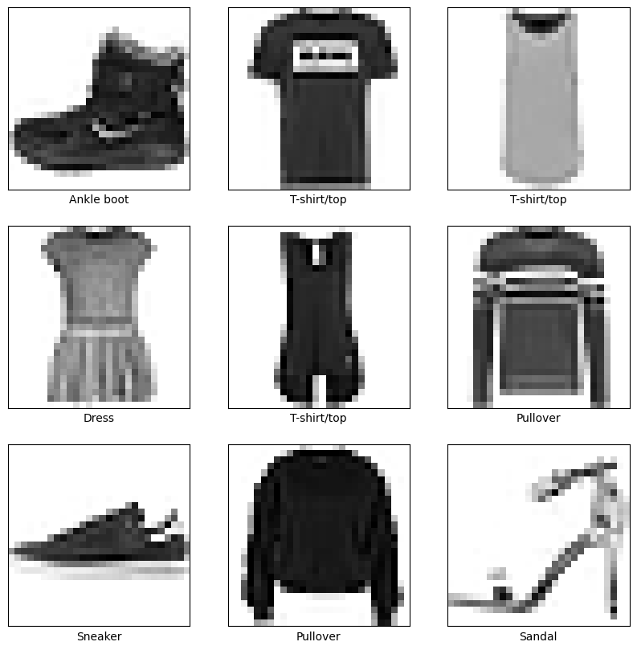

```python
# show some examples of what we are working with
plt.figure(figsize=(10, 10))
for i in range(9):
    plt.subplot(3, 3, i+1)
    plt.xticks([])
    plt.yticks([])
    plt.grid(False)
    plt.imshow(x_train[i], cmap=plt.cm.binary)
    plt.xlabel(class_names[y_train[i]])
plt.show()
```

## Data Augmentation

```python
from tensorflow.keras.preprocessing.image import ImageDataGenerator
```

```python
# normalize images
x_train = x_train.reshape(-1, 28, 28, 1).astype('float32') / 255.0
x_test = x_test.reshape(-1, 28, 28, 1).astype('float32') / 255.0
```

```python
# apply data augmentation
datagen = ImageDataGenerator(
    rotation_range=15, # randomly rotate in range 15 degrees
    width_shift_range=0.1, # randomly shifts images horizontally up to 10% of the width
    height_shift_range=0.1, # randomly shifts images vertically up to 10% of the height
    shear_range=0.1, # applies random shearing transformations up to 10 degrees
    zoom_range=0.1, # randomly zooms images in or out by up to 10%
    featurewise_center=True, # normalizes the dataset by subtracting the mean value of the training set
    featurewise_std_normalization=True, # normalizes the dataset by dividing by the standard deviation of the training set
    horizontal_flip=False # prevents flipping the image horizontally, important for non-symmetrical data like Fashion-MNIST
)

datagen.fit(x_train)
```

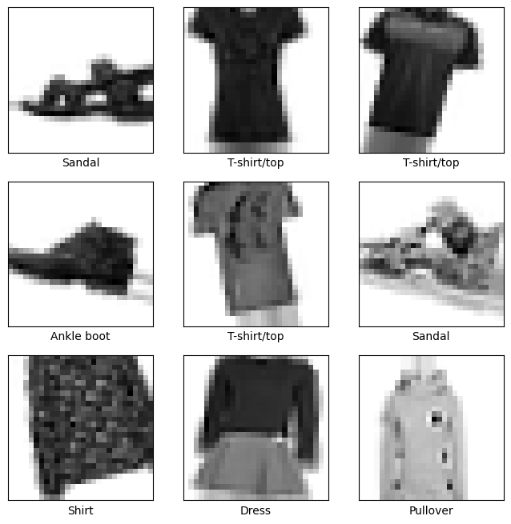

```python
# visualize augmented data
augmented_images, augmented_labels = next(datagen.flow(x_train, y_train, batch_size=9))

plt.figure(figsize=(8, 8))
for i in range(9):
    plt.subplot(3, 3, i+1)
    plt.xticks([])
    plt.yticks([])
    plt.grid(False)
    plt.imshow(augmented_images[i].reshape(28, 28), cmap=plt.cm.binary)
    plt.xlabel(class_names[augmented_labels[i]])
plt.show()
```

## Dimensionality Reduction using PCA

```python
from sklearn.decomposition import PCA
import cv2
```

```python
# flatten images
x_train_flat = x_train.reshape(-1, 28*28)
```

```python
# apply PCA
pca = PCA(n_components=40)
x_train_pca = pca.fit_transform(x_train_flat)
```

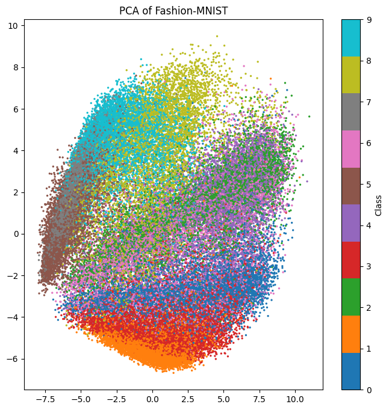

```python
# visualize PCA results
plt.figure(figsize=(8, 8))
scatter = plt.scatter(x_train_pca[:, 0], x_train_pca[:, 1],
                      c=y_train, cmap='tab10', s=2)
plt.colorbar(scatter, ticks=range(10), label="Class")
plt.title("PCA of Fashion-MNIST")
plt.show()
```

PCA helps reduce dimensionality while preserving variance. However, the overlap of colours, which are classes, suggests that PCA in 2D may not completely separate the classes. This indicates that the dataset has inherent overlap in feature space, making it challenging to linearly separate classes with only two principal components.

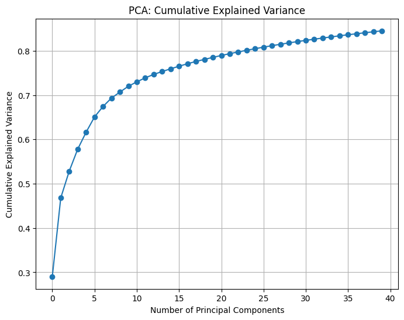

```python
# diagram of explained variance fro PCA
plt.figure(figsize=(8, 6))
plt.plot(np.cumsum(pca.explained_variance_ratio_), marker='o')
plt.title("PCA: Cumulative Explained Variance")
plt.xlabel("Number of Principal Components")
plt.ylabel("Cumulative Explained Variance")
plt.grid()
plt.show()
```

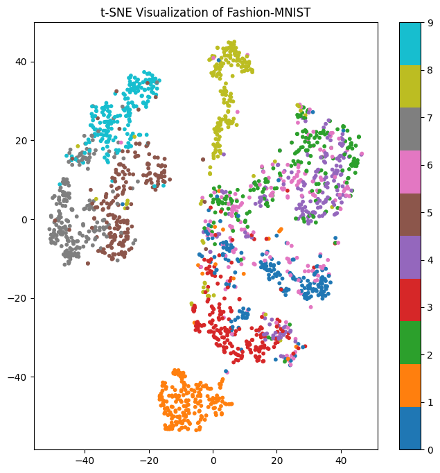

```python
from sklearn.manifold import TSNE

tsne = TSNE(n_components=2, random_state=42)
tsne_result = tsne.fit_transform(x_train_pca[:2000])

plt.figure(figsize=(8, 8))
scatter = plt.scatter(tsne_result[:, 0], tsne_result[:, 1], c=y_train[:2000], cmap='tab10', s=10)
plt.colorbar(scatter)
plt.title("t-SNE Visualization of Fashion-MNIST")
plt.show()
```

t-SNE is non-linear, and excels at capturing local structures, making it more suitable for visualizing complex datasets like Fashion-MNIST. t-SNE is better than PCA for visualizing separability and relationships among classes in lower dimensions.

Some clusters are more distinct; class 1 for example, compared to others, suggesting that certain classes are inherently more separable. Despite clearer separation, some overlap between certain classes still exists, indicating potential similarity or ambiguity in their features. This overlap is not all bad, as classes 5, 7, and 9 are out on their own, they are all footwear, which was successfully captured by t-SNE.

Similarly, the orange cluster at the bottom are trousers, and the slim yellow cluster at the top are bags!

```python
!pip install nbconvert
```

```python
!jupyter nbconvert /content/JohnsonCA2.ipynb --to html
```

[output not shown]

[output cut: 136 more lines]

[output not shown]